# Caso 3. Regresión Lineal Múltiple con datos Adverstising. Programación R

Luis Alberto Jimenez Soto

2022-09-29

# 1 Objetivo

Crear y evaluar un modelo de regresión lineal múltiple para predecir las ventas con datos simulados de una empresa dependiendo de las inversiones realizadas en publicidad

# 2 Descripción

- Cargar librerías y datos
- Limpiar datos si es necesario
- Explorar datos
- Partir los datos en datos de entrenamiento y datos de validación 70% y 30%
- Crear modelo de regresión con los datos de entrenamiento
- Evaluar modelo antes de predicciones con los estadísticos. *R Square* ajustado y Coeficientes
- El modelo se acepta si presenta un valor de *R Square* ajustado por encima del 70%
- Predicciones
- Evaluar predicciones con respecto a datos reales
- Determinar el estadístico *rmse* para evaluar con respecto a otros modelos
- Interpretar el caso

# 3 Fundamento teórico

En la mayoría de los problemas de investigación en los que se aplica el análisis de regresión se necesita más de una variable independiente para el modelo de regresión.

La complejidad de la mayoría de mecanismos científicos es tal que, con el fin de predecir una respuesta importante, se requiere un modelo de regresión múltiple. Cuando un modelo es lineal en los coeficientes se denomina modelo de regresión lineal múltiple.

Para el caso de k variables independientes, $x_1,x_2,x_3…,x_k$, y $y$ como la variable dependiente.

$x_1, x_2, x_3,...,x_k$ son las variable s que afectan a la variable dependiente en el modelo de regresión lineal múltiple.

Muchos problemas de investigación y de la industria, requieren la estimación de las relaciones existentes entre el patrón de variabilidad de una variable aleatoria y los valores de una o más variables aleatorias. [@urrutiamosquera2011]

Al generar un modelo de regresión lineal múltiple es importante identificar los estadísticos de R2, que se denomina coeficiente de determinación y es una medida de la proporción de la variabilidad explicada por el modelo ajustado.

De igual forma, el valor de R2 ajustado (*R Square Adjusted*) o coeficiente de determinación ajustado, es una variación de R2 que proporciona un ajuste para los grados de libertad [@walpole2012].

El estadístico R Ajustado está diseñado para proporcionar un estadístico que castigue un modelo sobreajustado, de manera que se puede esperar que favorezca al modelo [@walpole2012].

Una variable **Y** puede predecirse conforme y de acuerdo con la siguiente fórmula de la regresión múltiple.

$$Y = b_0 + b_1{x_1} + b_2{x_2} + b_3{x_3}+ …..b_k{x_k}$$

# 4 Desarrollo

## 4.1 Cargar librerías

```r
library(dplyr)
library(ggplot2)
# library(plotly) # no se está usando
library(knitr)
library(PerformanceAnalytics) # Para correlaciones gráficas
library(caret)  # Para particionar
library(Metrics) # Para determinar rmse
library(PerformanceAnalytics) # Para cor gráfica
```

## 4.2 Cargar datos

```r
datos <- read.csv("https://raw.githubusercontent.com/rpizarrog/Analisis-Inteligente-de-datos/main/datos/Advertising_Web.csv")
```

## 4.3 Explorar datos

```r
str(datos)
```

```
## 'data.frame':    200 obs. of  7 variables:
##  $ X.1      : int  1 2 3 4 5 6 7 8 9 10 ...
##  $ X        : int  1 2 3 4 5 6 7 8 9 10 ...
##  $ TV       : num  230.1 44.5 17.2 151.5 180.8 ...
##  $ Radio    : num  37.8 39.3 45.9 41.3 10.8 48.9 32.8 19.6 2.1 2.6 ...
##  $ Newspaper: num  69.2 45.1 69.3 58.5 58.4 75 23.5 11.6 1 21.2 ...
##  $ Web      : num  306.6 302.7 49.5 257.8 195.7 ...
##  $ Sales    : num  22.1 10.4 9.3 18.5 12.9 7.2 11.8 13.2 4.8 10.6 ...
```

```r
summary(datos)
```

```
##       X.1               X                TV             Radio
##  Min.   :  1.00   Min.   :  1.00   Min.   :  0.70   Min.   : 0.000
##  1st Qu.: 50.75   1st Qu.: 50.75   1st Qu.: 74.38   1st Qu.: 9.975
##  Median :100.50   Median :100.50   Median :149.75   Median :22.900
##  Mean   :100.50   Mean   :100.50   Mean   :147.04   Mean   :23.264
##  3rd Qu.:150.25   3rd Qu.:150.25   3rd Qu.:218.82   3rd Qu.:36.525
##  Max.   :200.00   Max.   :200.00   Max.   :296.40   Max.   :49.600
##    Newspaper           Web              Sales
##  Min.   :  0.30   Min.   :  4.308   Min.   : 1.60
##  1st Qu.: 12.75   1st Qu.: 99.049   1st Qu.:10.38
##  Median : 25.75   Median :156.862   Median :12.90
##  Mean   : 30.55   Mean   :159.587   Mean   :14.02
##  3rd Qu.: 45.10   3rd Qu.:212.312   3rd Qu.:17.40
##  Max.   :114.00   Max.   :358.247   Max.   :27.00
```

### 4.3.1 Limpiar datos

Quitar las primeras columnas

```r
datos <- select(datos, TV, Radio, Newspaper, Web, Sales)
```

### 4.3.2 Correlaciones lineal entre variables

```r
cor(datos)
```

```
##                   TV       Radio   Newspaper         Web      Sales
## TV        1.00000000  0.05480866  0.05664787  0.01257597 0.78222442
## Radio     0.05480866  1.00000000  0.35410375 -0.12267338 0.57622257
## Newspaper 0.05664787  0.35410375  1.00000000 -0.05775877 0.22829903
## Web       0.01257597 -0.12267338 -0.05775877  1.00000000 0.00210779
## Sales     0.78222442  0.57622257  0.22829903  0.00210779 1.00000000
```

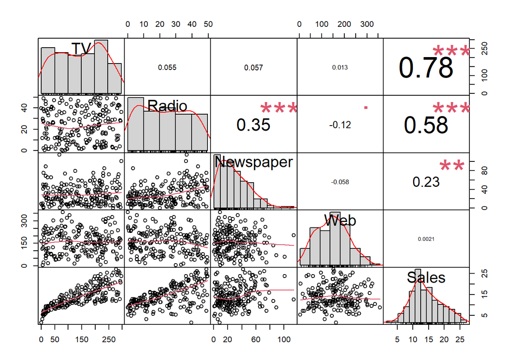

```r
chart.Correlation(datos)
```

### 4.3.3 Las variables de interés

- x’s las variable independientes o predictoras son TV, Radio, Newspaper y Web
- y la variable dependiente o resultado (Sales), es decir que depende de las variables x’s.

## 4.4 Limpiar datos

En caso necesario. No se observan datos extraños …. porque son pocos.

## 4.5 Partir datos

Aleatoriamente se reparten las observaciones con el 70% para datos de entrenamiento y el 30% para datos de validación.

Sembrar una semilla con set.seed()

```r
set.seed(1271)
```

```r
n <- nrow(datos)  # cantidad de observaciones
```

```r
entrena <- createDataPartition(y = datos$Sales, p = 0.70, list = FALSE, times = 1)
# Datos entrenamiento
datos.entrenamiento <- datos[entrena, ]  # [renglones, columna]
# Datos validación
datos.validacion <- datos[-entrena, ]
```

### 4.5.1 Datos de entrenamiento

```r
datos.entrenamiento
```

```
##        TV Radio Newspaper        Web Sales
## 2    44.5  39.3      45.1 302.653070  10.4
## 3    17.2  45.9      69.3  49.498908   9.3
## 4   151.5  41.3      58.5 257.816893  18.5
## 5   180.8  10.8      58.4 195.660076  12.9
## 6     8.7  48.9      75.0  22.072395   7.2
## 8   120.2  19.6      11.6 229.971459  13.2
## 9     8.6   2.1       1.0 144.617385   4.8
## 11   66.1   5.8      24.2  45.359029   8.6
## 12  214.7  24.0       4.0 164.971764  17.4
## 13   23.8  35.1      65.9  87.921085   9.2
## 14   97.5   7.6       7.2 173.658035   9.7
## 15  204.1  32.9      46.0 245.774960  19.0
## 18  281.4  39.6      55.8  41.755313  24.4
## 21  218.4  27.7      53.4  59.960554  18.0
```

[output cut: 128 more lines]

### 4.5.2 Datos de validación

```r
datos.validacion
```

```
##        TV Radio Newspaper        Web Sales
## 1   230.1  37.8      69.2 306.634752  22.1
## 7    57.5  32.8      23.5 246.811598  11.8
## 10  199.8   2.6      21.2 111.272264  10.6
## 16  195.4  47.7      52.9 148.095134  22.4
## 17   67.8  36.6     114.0 202.638903  12.5
## 19   69.2  20.5      18.3 210.489910  11.3
## 20  147.3  23.9      19.1 268.735384  14.6
## 23   13.2  15.9      49.6 219.882776   5.6
## 37  266.9  43.8       5.0  96.316829  25.4
## 39   43.1  26.7      35.1 122.753591  10.1
## 42  177.0  33.4      38.7 147.859324  17.1
## 43  293.6  27.7       1.8 174.716820  20.7
## 46  175.1  22.5      31.5  62.809264  14.9
## 49  227.2  15.8      49.9  75.269182  14.8
```

[output cut: 44 more lines]

## 4.6 Construir el modelo

El modelo se construye con datos de entrenamiento

Modelo de Regresión Múltiple o Multivarido

$$Y <- \beta_0 + \beta_1 \cdot X_1 + \beta_2\cdot X_2 +\beta\cdot X_3
+...+ \beta_n\cdot X_n$$

```r
modelo_rm <- lm(data = datos.entrenamiento, formula = Sales ~ TV + Radio + Newspaper + Web)
summary(modelo_rm)
```

```
##
## Call:
## lm(formula = Sales ~ TV + Radio + Newspaper + Web, data = datos.entrenamiento)
##
## Residuals:
##     Min      1Q  Median      3Q     Max
## -4.9126 -0.8583  0.3535  1.0963  2.8833
##
## Coefficients:
##              Estimate Std. Error t value Pr(>|t|)
## (Intercept)  2.330976   0.460626   5.060 1.32e-06 ***
## TV           0.044771   0.001572  28.480  < 2e-16 ***
## Radio        0.193690   0.009906  19.552  < 2e-16 ***
## Newspaper   -0.002182   0.006731  -0.324   0.7463
## Web          0.003820   0.001710   2.234   0.0271 *
## ---
## Signif. codes:  0 '***' 0.001 '**' 0.01 '*' 0.05 '.' 0.1 ' ' 1
##
## Residual standard error: 1.606 on 137 degrees of freedom
## Multiple R-squared:  0.9024, Adjusted R-squared:  0.8995
## F-statistic: 316.7 on 4 and 137 DF,  p-value: < 2.2e-16
```

Los coeficientes TV y Radio presentan niveles de confianza por encima del 99.9%; *Newspaper* no presenta un nivel de confianza por encima del 90%, por lo cual puede pensarse en despreciar esa variable para futuros análisis; el coeficiente para WEB presenta un nivel de confianza del 95%.

## 4.7 Evaluar el modelo antes de predicciones

Fómula Rsquare Ajustado

[figure not shown]

El valor del *R Square* se interpreta que tanto las variables la variabilidad de las ventas. El valor del *R Square* ajustado es expresa que hay buen ajuste entre los datos reales y los datos modelados de predicción [@urrutiamosquera2011].

Ese valor, se compara contra un métrica inicial esperada que seguramente se define para hablar de que si esta conforme a lo esperado. Por ejemplo se esperaba que este valor estuviera por encima del 70% de tal forma que el modelo si cumple con esa expectativa y el modelo se acepta.

## 4.8 Hacer predicciones

Se hacen predicciones con los datos de validación.

```r
predicciones <- predict(object = modelo_rm, newdata = datos.validacion)
# predicciones
```

Construir un *data frame* llamado comparaciones para comparar los datos reales contra los datos predichos y servirán para identificar el estadístico *rmse*.

```r
comparaciones <- data.frame(datos.validacion, predicciones)
comparaciones
```

```
##        TV Radio Newspaper        Web Sales predicciones
## 1   230.1  37.8      69.2 306.634752  22.1    20.974462
## 7    57.5  32.8      23.5 246.811598  11.8    12.149781
## 10  199.8   2.6      21.2 111.272264  10.6    12.158527
## 16  195.4  47.7      52.9 148.095134  22.4    20.768463
## 17   67.8  36.6     114.0 202.638903  12.5    12.980786
## 19   69.2  20.5      18.3 210.489910  11.3    10.163819
## 20  147.3  23.9      19.1 268.735384  14.6    14.539688
## 23   13.2  15.9      49.6 219.882776   5.6     6.733272
## 37  266.9  43.8       5.0  96.316829  25.4    23.120910
## 39   43.1  26.7      35.1 122.753591  10.1     9.824418
## 42  177.0  33.4      38.7 147.859324  17.1    17.204987
## 43  293.6  27.7       1.8 174.716820  20.7    21.504307
## 46  175.1  22.5      31.5  62.809264  14.9    14.699551
## 49  227.2  15.8      49.9  75.269182  14.8    15.741831
```

[output cut: 44 more lines]

## 4.9 Evaluar predicciones

*rmse* Root Mean Stándard Error (*Root-mean-square deviation*), este valor normalmente se compara contra otro modelo y el que esté mas cerca de cero es mejor.

La raiz del Error Cuadrático Medio (*rmse*) es una métrica que dice qué tan lejos están los valores predichos de los valores observados o reales en un análisis de regresión, en promedio. Se calcula como:

$$rmse = \sqrt{\frac{\sum(predicho_i - real_i)^{2}}{n}}$$

*RMSE* es una forma útil de ver qué tan bien un modelo de regresión puede ajustarse a un conjunto de datos.

Cuanto mayor sea el *rmse*, mayor será la diferencia entre los valores predichos y reales, lo que significa que peor se ajusta un modelo de regresión a los datos. Por el contrario, cuanto más pequeño sea el rmse, mejor podrá un modelo ajustar los datos.

```r
rmse <- rmse(actual = comparaciones$Sales, predicted = comparaciones$predicciones)
rmse
```

```
## [1] 1.797079
```

## 4.10 Graficar prediciones contra valores reales

El gráfico lineal en color azul refleja las predicciones reales y en color amarillo las predicciones hechas por el modelo, las diferencias son las que se cocentran en el estadístico *rmse*.

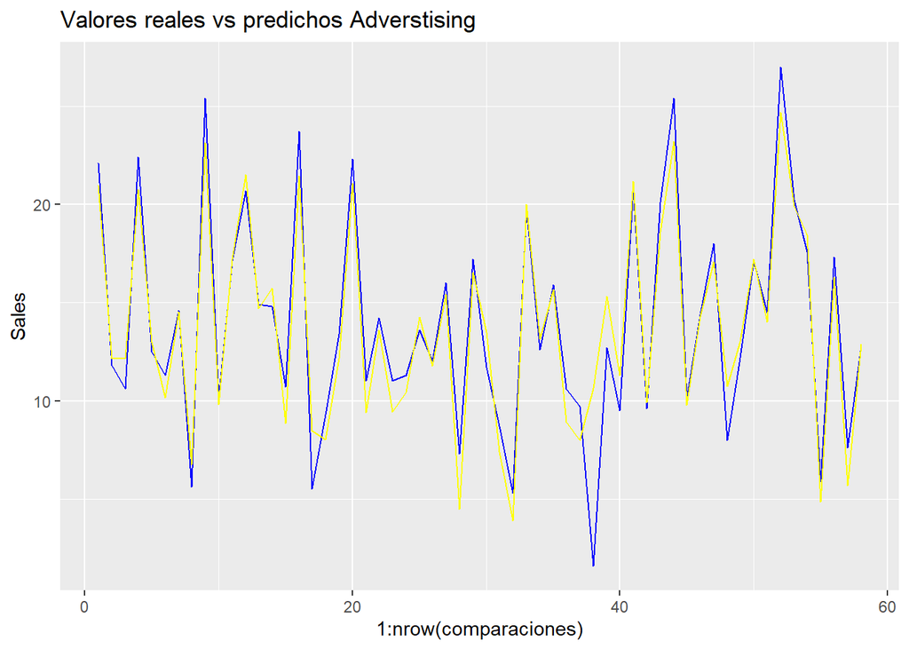

```r
ggplot(data = comparaciones) +
  geom_line(aes(x = 1:nrow(comparaciones), y = Sales), col='blue') +
  geom_line(aes(x = 1:nrow(comparaciones), y = predicciones), col='yellow') +
  ggtitle(label="Valores reales vs predichos Adverstising")
```

## 4.11 Predicciones con datos nuevos

Se hacen predicciones con datos nuevos.

```r
TV <- c(140, 160)
Radio <- c(60, 40)
Newspaper <- c(80, 90)
Web <- c(120, 145)

nuevos <- data.frame(TV, Radio, Newspaper, Web)
nuevos
```

```
##    TV Radio Newspaper Web
## 1 140    60        80 120
## 2 160    40        90 145
```

```r
Y.predicciones <- predict(object = modelo_rm, newdata = nuevos)
Y.predicciones
```

```
##        1        2
## 20.50412 17.59940
```

# 5 Interpretación

Pendiente …

Con este modelo y con estos datos interprete lo siguiente:

- ¿Cuál es el contexto de los datos?

Una empresa está comparando las ventas de algún producto con respecto a la inversion en anuncios que se tienen en distintos medios.

- ¿Cuántas observaciones se analizan y cuáles son las variables de interés?

Se analizaron 200 observaciones, teniendo como variables de interés: TV, Radio, Newspaper, Web y Sales.

- ¿Cuáles son las variables independientes y dependientes?

Las variables independientes son TV, Radio, Newspaper y Web, la variable dependiente es Sales.

- ¿Cuál es el porcentaje de datos de entrenamiento y datos de validación ? Los datos que sirvieron de entrenamiento son el 70%, los de validación son el 30%
- ¿Son los coeficientes confiables al menos al 90% para hacer predicciones?, TV, Radio y Web tienen una confiabilidad mayor al 90%
- ¿Cuál nivel de confianza para cada coeficiente?

- ¿Que valor tiene el estadístico el *R Square* ajustado y que representa o qué significa?

El valor de R Square ajustado es de 0.8995 y representa qué tan bien se ajusta el modelo a los datos

- ¿Cuál es el valor de *RMSE* y qué significaría este valor

El valor de RMSE es de 1.797079, significa que las predicciones tendrán una diferencia de 1.79 aproximadamente

- ¿Puede haber otro modelo más óptimo para estos datos?

Si pero requeriría de otras operaciones, como por ejemplo podría ser una regresión lineal múltiple con más de una variable dependiente o más variables independientes.

- ¿Que tan confiables son las predicciones con datos nuevos con este modelo y con estos datos?

Tomando en cuenta los datos de correlación, el R Square y el RMSE, se puede concluir que este modelo, con la semilla 1271, tiene un grado de certeza muy alto, perfecto para su posterior uso en predicciones, simulaciones, etc.